# Python机器学习进阶之深度学习

## Python机器学习进阶之深度学习

与[Python机器学习示例](https://shixiangwan.github.io/notebook/machine_learning_with_python.html)类似，这个教程难度稍有增加，侧重于应用深度学习在生物信息学中的一些实现。

深度学习已经在生物信息学中有很多应用，[deeplearning-biology项目](https://github.com/hussius/deeplearning-biology)中持续更新关于这方面的文章，这里简单列举几篇：

- **DeepSEA:** Zhou J, Troyanskaya O G. Predicting effects of noncoding variants with deep learning–based sequence model[J]. Nature Methods, 2015, 12(10):931.

该深度学习模型输入是长为1000bp的DNA序列，每个样本进行one-hot编码后形成1000*4的0-1特征矩阵，连接卷积层、池化层和全连接层，最终实现分类预测。

- **DeepCpG:** Angermueller C, Lee H J, Reik W, et al. DeepCpG: accurate prediction of single-cell DNA methylation states using deep learning[J]. Genome Biology, 2017, 18(1):67.

该深度学习模型输入是长为501bp的DNA序列，每个样本进行one-hot编码后形成501*4的0-1特征矩阵，连接卷积层、池化层和全连接层，最终实现分类预测。

- **DeepBind:** Alipanahi B, Delong A, Weirauch M T, et al. Predicting the sequence specificities of DNA- and RNA-binding proteins by deep learning[J]. Nature Biotechnology, 2015, 33(8):831.

该深度学习模型输入是长度在14–101nt之间的DNA序列，每个序列分别找出一个长为M的Motif，这些Motif可以转成PWM（位置权重矩阵）。因此输入就变成了4*M的矩阵，这就是原始的输入。这个矩阵将连接卷积层、池化层、全连接层等组成的卷积神经网络，最终完成分类任务。

- **DeeperBind:** Hassanzadeh H R, Wang M D. DeeperBind: Enhancing Prediction of Sequence Specificities of DNA Binding Proteins[J]. 2016.

该深度学习模型是DeepMind的升级版，加入了递归神经网络与卷积神经网络相结合。DeepMind能够对低级的Motif特征进行高层特征抽取，结构设计也非常精炼。但是，它先入为主地假设了每个序列中至多只有一个motif，这会误导神经网络的训练过程。例如这样一种不那么罕见的情形：由于某些局部序列的突出贡献，也会出现较好的motif。此时，模型将尝试微调motif检测器的kernels权重，使得局部较好motif受到较大惩罚来追求全局最优解。此外，由于只检测一个motif，由于技术的限制也不能保证这个motif就是全局最优解。最终，卷积神经网络会陷入捕捉短期 motif（short-term (nucleotide level)）而忽略长期（long-term (motif level)）特征的困境。 motif之间的长期重要性是由于motif探针之间的互相关系产生的；motif之间的短期重要性则是由于DNA和Protein的高阶结构之间的互相关联产生的。由此，文章考虑递归神经网络（Recurrent Neural Network (RNN)），这个网络模型的优势在于考虑了时间/位置上的深度。

值得一提的是，该论文还提到了为什么应用于图像识别的CNN能够用于生物序列研究：

> Models based on convolutional neural networks (CNNs) have become an integral part of the winner models in almost every image processing contest these days. This was perhaps the major motivation for transforming DNA sequences into image-like modalities rendering them amenable to deep models. In fact, the same way that pixel values in a 2D image depend on the neighboring pixels, the set of nucleotides in a DNA locus that has a specific function (such as a promoter) are not just a random assortment of nucleotides and hence can be treated as a 1D image. Not only that, the set of nearby pixels (nucleotides) often exhibit stationary patterns which obviate the need for deploying fully connected layers until the last stages of deep pipelines. Additionally, the convolution operation is fundamentally similar to scanning sequences with PWM (position weight matrix) filters which was once the basis for promising solutions that characterize motifs. Therefore, it is favorable to take advantage of these powerful models in a deep way to benefit from the recent optimization techniques and pattern recognition paradigms.

------------------------------------------- 正经的分割线 -------------------------------------------------

接下来，我们将追随DeepMind论文的思路，探究如何利用Motif生成基础特征和深度学习提取高级特征（one-hot生成基础特征要求序列都要等长，不符合我们这里的需求，但比较简单，大家可以自己去实现）。

我们将使用:

- [MEME](http://meme-suite.org/doc/meme.html)来得到序列的Motif；
- [sklearn](http://scikit-learn.org/stable/)来优雅地完成机器学习分类任务；
- [imblearn](http://contrib.scikit-learn.org/imbalanced-learn/)来处理不平衡数据；
- [seaborn](http://seaborn.pydata.org/api.html)来绘制简单且美观的统计图；
- [mxnet](http://mxnet.io/)来探索结构简单的卷积神经网络模型，并从中抽取高级特征。

原始数据说明：

- RNA_Locate_Homo.fasta：fasta格式人类RNA序列，有26077条；
- RNA_Locate_Homo_Lab.txt：csv格式定位标签，有26077条，每条39个定位；
- RNA_Locate_Homo_Motifs.csv：csv格式，Motifs产生的PWM基础特征，每条60维；
- RNA_Locate_Homo_Motifs_Lab.csv：csv格式定位标签，与RNA_Locate_Homo_Motifs.csv样本数相匹配。

原始数据及相关论文下载：  
链接：http://pan.baidu.com/s/1gfAFVjH 密码：0avc

```python
# 常用基本包
import os
import time
import numpy as np
import pandas as pd

# 用于Fasta序列快速处理
from pyfaidx import Fasta

# 用于机器学习
from sklearn import metrics
from sklearn import ensemble
from sklearn import decomposition
from sklearn import model_selection

# 用于不平衡数据处理
from imblearn.combine import SMOTETomek

# 用于深度学习
# 优点是速度快、占用显存少
import mxnet as mx

# 用于绘图
%matplotlib inline
import seaborn as sns
color = sns.color_palette()

# 日志记录级别
import logging
logging.basicConfig(level=logging.INFO)
```

### 1. 生成Motif作为输入数据

- 输入：26077条长度在16~325852bp之间的RNA序列，以及其39个亚细胞定位标签（维度：26077*39）
- 输出：能够提取出Motif的26077-1280=24797条样本（每个样本维度：15*4），以及其对应的标签
- 步骤：
  - 利用[MEME](http://meme-suite.org/doc/meme.html)生成各个序列的motif文件
  - 在Motif结果文件中，提取letter-probability matrix作为样本输入数据

```python
pwm, lab = [], []
error, count = 0, 0
path = "/home01/shixiangwan/MEME_for_motifs/RNA_Locate_Homo/"

# 将标签矩阵准备好
labels = pd.read_csv("/home01/shixiangwan/deep_learning/protein_location/data/RNA_Locate_Homo_Lab.txt").values

for fasta in Fasta("/home01/shixiangwan/deep_learning/protein_location/data/RNA_Locate_Homo.fasta"):

    # 先提出每个单独的文件
    test_file = open(path+"test.fasta", "w")
    test_file.write(">" + fasta.name + "\n")
    test_file.write(str(fasta) + "\n")
    test_file.close()

    try:
        # 再生成motif文件
        # 刷新环境变量并运行MEME
        command = "source /etc/profile; meme"+" "+path+"test.fasta"+" "+"-rna"+" "+"-mod anr -w 15 -maxsize 330000 -oc "+path
        os.popen(command)

        # 将输出文件meme.txt中的letter-probability matrix转为一行字符串存起来
        meme = open(path+"meme.txt").readlines()
        start = [i for i in range(len(meme)) if meme[i].find("letter-probability matrix") != -1][0]
        matrix = ','.join([line.strip().replace('  ', ',') for line in meme[start+1:start+16]])
        # print matrix
        pwm.append(matrix)
        lab.append(','.join(map(str, labels[count])))

        os.system("rm "+path+"meme.txt")
    except:
        # 可能的错误有：meme.txt结果中由于序列过短没有letter-probability matrix或者meme命令出错等
        error += 1
        print 'ERROR:', ">" + fasta.name, str(fasta)
        continue

    count += 1
    if count%100 == 0:
        print time.ctime(), "Current number:", count

print "不能提出Motif的样本数:", error
```

```
不能提出Motif的样本数: 1280
```

```python
# 考察去重后的样本数
print '去重后的样本数:', pd.DataFrame(pwm).drop_duplicates().shape[0]
```

```
去重后的样本数: 17854
```

```python
# 将letter-probability matrix存入RNA_Locate_Homo_Motifs.csv
pwm_feature = open(path+"RNA_Locate_Homo_Motifs.csv", "w")
for line in pwm:
    pwm_feature.write(line+"\n")
pwm_feature.close()

# 将正确匹配的标签存入RNA_Locate_Homo_Motifs_Lab.csv
# 因为有一部分序列过短而没有达到要求的motif，这些样本不予考虑
pwm_feature = open(path+"RNA_Locate_Homo_Motifs_Lab.csv", "w")
for line in lab:
    pwm_feature.write(line+"\n")
pwm_feature.close()
```

### 2. 导入Motif特征

```python
# 分别载入上面提取出的Motifs特征和多标签文件
motifs = pd.read_csv("/home01/shixiangwan/MEME_for_motifs/RNA_Locate_Homo/RNA_Locate_Homo_Motifs.csv", header=None)
labels = pd.read_csv("/home01/shixiangwan/MEME_for_motifs/RNA_Locate_Homo/RNA_Locate_Homo_Motifs_Lab.csv", header=None)
labels.columns = pd.read_csv("/home01/shixiangwan/deep_learning/protein_location/data/RNA_Locate_Homo_Lab.txt").columns

print motifs.shape
print labels.shape
print labels.columns
```

```
(24797, 60)
(24797, 39)
Index([u'Anterior', u'Apical', u'Axon', u'Basal', u'Cell body', u'Cell cortex',
       u'Cell junction', u'Cell leading edge', u'Cellular bud', u'Centrosome',
       u'Chloroplast', u'Circulating', u'Cytoplasm', u'Cytoskeleton',
       u'Cytosol', u'Dendrite', u'Dorsal', u'Endoplasmic reticulum',
       u'Exosome', u'Extracellular vesicle', u'Germ plasm', u'Golgi apparatus',
       u'Growth cone', u'Lamellipodium', u'Lysosome', u'Microvesicle',
       u'Mitochondrion', u'Mitotic spindle', u'Nucleolus', u'Nucleoplasm',
       u'Nucleus', u'Perinuclear', u'Peroxisome', u'Posterior',
       u'Pseudopodium', u'Ribosome', u'Somatodendritic compartment',
       u'Synapse', u'Vegetal'],
      dtype='object')
```

```python
# 以第一个样本为例，观察样本数据
# 每个样本为4*15的矩阵，4行分别代表A、T、C、G，15列代表Motif的PWM值
pd.DataFrame(motifs.values[0].reshape((15, 4)).T)
```

|  | 0 | 1 | 2 | 3 | 4 | 5 | 6 | 7 | 8 | 9 | 10 | 11 | 12 | 13 | 14 |
| --- | --- | --- | --- | --- | --- | --- | --- | --- | --- | --- | --- | --- | --- | --- | --- |
| 0 | 0.0 | 0.00 | 0.0 | 0.25 | 0.0 | 0.00 | 0.25 | 0.25 | 0.00 | 0.0 | 0.0 | 0.0 | 0.75 | 0.00 | 0.0 |
| 1 | 0.0 | 0.50 | 0.0 | 0.75 | 0.0 | 0.25 | 0.75 | 0.25 | 0.25 | 0.0 | 0.0 | 0.0 | 0.00 | 0.75 | 0.0 |
| 2 | 0.0 | 0.25 | 0.0 | 0.00 | 0.0 | 0.25 | 0.00 | 0.00 | 0.25 | 0.0 | 1.0 | 1.0 | 0.25 | 0.25 | 0.0 |
| 3 | 1.0 | 0.25 | 1.0 | 0.00 | 1.0 | 0.50 | 0.00 | 0.50 | 0.50 | 1.0 | 0.0 | 0.0 | 0.00 | 0.00 | 1.0 |

### 3. 传统机器学习方法

```python
def machine_learning(X, y):
    classifier = ensemble.RandomForestClassifier()

    y_pred_cv = model_selection.cross_val_predict(classifier, X, y, cv=10, n_jobs=8, method='predict')

    print "Accuracy:", metrics.accuracy_score(y, y_pred_cv)
    print "F1:", metrics.f1_score(y, y_pred_cv)
    print "MCC:", metrics.matthews_corrcoef(y, y_pred_cv)

# 随机森林10折交叉验证
X, y = motifs.values, labels['Nucleus'].values
machine_learning(X, y)
```

```
Accuracy: 0.740170181877
F1: 0.159425962166
MCC: 0.0908630463298
```

可以看到，尽管Accuracy值高，但F1值和MCC值很低，说明数据很可能是不平衡的，造成Recall非常低。由此，绘制类别分布图如下：

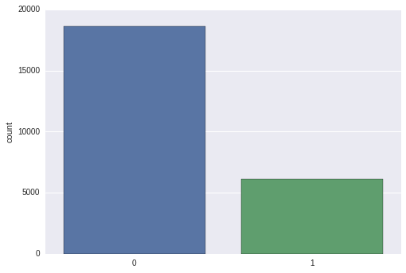

```python
sns.countplot(y)
```

可以看到，类别分布不均衡，考虑利用SMOTE+Tomek生成平衡数据集。

```
INFO:imblearn.base:Compute classes statistics ...
INFO:imblearn.base:2 classes detected: Counter({0: 18656, 1: 6141})
INFO:imblearn.base:Compute classes statistics ...
INFO:imblearn.base:2 classes detected: Counter({0: 18656, 1: 6141})
INFO:imblearn.base:Generated 12515 new samples ...
INFO:imblearn.base:Compute classes statistics ...
INFO:imblearn.base:2 classes detected: Counter({0: 18656, 1: 18656})
INFO:imblearn.base:Under-sampling performed: Counter({0: 18656, 1: 18619})
```

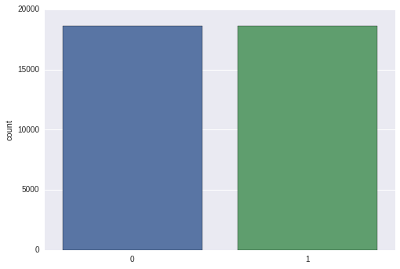

```python
# 生成平衡数据集
smote = SMOTETomek(random_state=2017)
X_sm, y_sm = smote.fit_sample(X, y)

# 观察分布情况
sns.countplot(y_sm)
```

```python
machine_learning(X_sm, y_sm)
```

```
Accuracy: 0.865325285044
F1: 0.859729518274
MCC: 0.732851139643
```

很明显，现在的结果更加均衡了。

接下来，考虑使用深度学习里的卷积神经网络提取高级特征。

### 4. 深度学习（CNN）

```python
# 定义卷积神经网络
def set_cnn(label_num):
    net = mx.symbol.Variable('data')
    # 卷积层
    net = mx.sym.Convolution(net, kernel=(2, 2), num_filter=4)
    net = mx.sym.Activation(net, act_type="tanh")
    net = mx.sym.Pooling(net, pool_type="max", kernel=(2, 2))
    # 全连接层
    net = mx.sym.Flatten(net)
    net = mx.symbol.FullyConnected(net, num_hidden=500)
    net = mx.sym.Activation(net, act_type="tanh")
    # 用于规约输出的全连接层，num_hidden数就是标签维度
    net = mx.sym.FullyConnected(net, num_hidden=label_num)
    # Softmax函数
    net = mx.sym.SoftmaxOutput(net, name='softmax')
    return net

# 观察网络结构
mx.viz.plot_network(set_cnn(1), hide_weights=False)
```

[figure not shown]

```python
# 准备数据（分割训练集和验证集）
X_train, X_valid, y_train, y_valid = model_selection.train_test_split(X, y, test_size=0.2, random_state=2017)
train_iter = mx.io.NDArrayIter(mx.nd.array(X_train.reshape(X_train.shape[0], 1, 15, 4)), mx.nd.array(y_train))
valid_iter = mx.io.NDArrayIter(mx.nd.array(X_valid.reshape(X_valid.shape[0], 1, 15, 4)), mx.nd.array(y_valid))

# 建模（也可使用4块GPU一起训练）
model = mx.mod.Module(symbol=set_cnn(1), context=mx.gpu(0))

# 参数
model_prefix = 'mx_cnn'
checkpoint = mx.callback.do_checkpoint(model_prefix)

# 训练
# 其他评价指标有： acc, ce (CrossEntropy), f1, mae, mse, rmse, top_k_accuracy
batch_size = 100
model.fit(train_iter, eval_data=valid_iter, optimizer='sgd', eval_metric='acc', num_epoch=2,
          epoch_end_callback=checkpoint, optimizer_params={'learning_rate':0.1},
          batch_end_callback=mx.callback.Speedometer(batch_size, 4000))
```

```
INFO:root:Epoch[0] Batch [4000]	Speed: 100908.38 samples/sec	Train-accuracy=0.749063
INFO:root:Epoch[0] Batch [8000]	Speed: 108157.77 samples/sec	Train-accuracy=0.752500
INFO:root:Epoch[0] Batch [12000]	Speed: 125284.94 samples/sec	Train-accuracy=0.750250
INFO:root:Epoch[0] Batch [16000]	Speed: 118613.72 samples/sec	Train-accuracy=0.760750
INFO:root:Epoch[0] Train-accuracy=0.746090
INFO:root:Epoch[0] Time cost=17.891
INFO:root:Saved checkpoint to "mx_cnn-0001.params"
INFO:root:Epoch[0] Validation-accuracy=0.754637
INFO:root:Epoch[1] Batch [4000]	Speed: 125133.51 samples/sec	Train-accuracy=0.749063
INFO:root:Epoch[1] Batch [8000]	Speed: 123343.24 samples/sec	Train-accuracy=0.752500
INFO:root:Epoch[1] Batch [12000]	Speed: 119720.58 samples/sec	Train-accuracy=0.750250
INFO:root:Epoch[1] Batch [16000]	Speed: 125045.60 samples/sec	Train-accuracy=0.760750
INFO:root:Epoch[1] Train-accuracy=0.746090
INFO:root:Epoch[1] Time cost=16.058
INFO:root:Saved checkpoint to "mx_cnn-0002.params"
INFO:root:Epoch[1] Validation-accuracy=0.754637
```

接下来，从上面的卷积神经网络中抽取高级特征，也就是找到卷积层后的输出。

```python
# 列出模型中的所有层
internals = model.symbol.get_internals()
internals.list_outputs()
```

```
['data',
 'convolution1_weight',
 'convolution1_bias',
 'convolution1_output',
 'activation2_output',
 'pooling1_output',
 'flatten1_output',
 'fullyconnected2_weight',
 'fullyconnected2_bias',
 'fullyconnected2_output',
 'activation3_output',
 'fullyconnected3_weight',
 'fullyconnected3_bias',
 'fullyconnected3_output',
 'softmax_label',
 'softmax_output']
```

```python
# 取第2回合后的参数
symbol, arg_params, aux_params = mx.model.load_checkpoint(model_prefix, 2)

# 确定新模型，该模型截取fullyconnected2_output，即卷积操作提取出的高层特征输出
new_symbol = internals['fullyconnected2_output']
new_model = mx.model.FeedForward(ctx=mx.gpu(1), symbol=new_symbol, numpy_batch_size=1,
                                 arg_params=arg_params, aux_params=aux_params, allow_extra_params=True)

# 输出高层特征
high_level_feature = new_model.predict(X.reshape(X.shape[0], 1, 15, 4))
print 'Shape of high level feature', high_level_feature.shape

# 随机森林10折交叉验证
machine_learning(high_level_feature, y)
```

```
[Deprecation Warning] mxnet.model.FeedForward has been deprecated. Please use mxnet.mod.Module instead.
Shape of high level feature (24797, 500)
Accuracy: 0.726660483123
F1: 0.137878402442
MCC: 0.0425677819912
```

卷积层参数多样，卷积网络的形式也可以或简单或丰富，更多内容留给大家去探索~~